# Regressing Labor Market Variables on State Level Anti-immigration Legislation: A Difference-in-Difference Approach

Yimin Guo

## Introduction

This is the core of the empirical side of our anti-immigration legislation study. To examine the impact of the law, we employed the modular approach in programming to conduct regression analysis on an extensive amount of county pairs. We defined two functions that does the regression and organizes the output, respectively. Doing so enables us to obtain any set of results we are interested by simply adjusting the input of the function.

Here I am only applying the functions to a small subset of our data. For more details on the regression results and our interpretation, please refer to the paper: [The Labor Market Effect of State Level Anti-immigration Legislation in the United States](https://www.researchgate.net/publication/352661030_The_Labor_Market_Effect_of_State_Level_Anti-Immigration_Legislation_in_the_United_States)

## Define Regression Function

In this project, we have to run tens of thousands of similar regressions. The best approach is to construct a function that takes a table as input, in which each row specifies a certain regression analysis to be conducted, and return a list of regression results that correspond to the table’s specification. This is the modular approach in programming, and the function we have here is called hb56reg:

```r
hb56reg = function(hb56_dt, qwi, countypairs) {

  try(file.remove(paste0('reg_result/logs/parlog.txt')))
  cl = makePSOCKcluster(ncore, outfile = paste0('reg_result/logs/parlog.txt'))
  registerDoParallel(cl)

  x = foreach(i = 1:nrow(hb56_dt),
              .packages = c('data.table', 'lfe', 'optiRum','tibble', 'stats'),
              .errorhandling = 'pass'
  ) %dopar% {

    # define the following items for easier reference
    i.state = hb56_dt[i,]$state
    i.race = hb56_dt[i,]$race
    i.ethnicity = hb56_dt[i,]$ethnicity
    i.industry = hb56_dt[i,]$industry
    i.education = hb56_dt[i,]$education
    i.lawStart = hb56_dt[i,]$lawStart
    i.lawEnd = hb56_dt[i,]$lawEnd
    i.depdVar = hb56_dt[i,]$depdVar
    i.regModel = hb56_dt[i,]$regModel
    i.nlead = hb56_dt[i,]$nlead


    # pull the group of states that this iteration will be looking at
    if (i.state == 1) {
      state_control = c(1,12,28,47)
    } else if (i.state == 4) {
      state_control = c(4,32,8,35,6)
    } else if (i.state == 13) {
      state_control = c(13,37,12,47)
    } else if (i.state == 18) {
      state_control = c(18,26,17,21,39)
    } else if (i.state == 45) {
      state_control = c(45,37)
    } else {
      state_control = c(49,32,16,56,8)
    }


    # create a dummy variable called treat_it that indicates if a county is treated at a certain time
    # treat_it will be the main independent variable in our regression
    z = qwi[list(state_control)] # uses key here, somewhat faster
    z = z[race == i.race & ethnicity == i.ethnicity
          & industry == i.industry & education == i.education]
    z = z[, treat_i := 0][, treat_t := 0]
    z[statefipsn %in% (c(1,4,13,18,45,49)), treat_i := 1]
    z[dt >= i.lawStart & dt <= i.lawEnd, treat_t := 1]
    z[, treat_it := treat_i * treat_t]
    z = z[, c(c("dt","geo","industry","race","ethnicity",
                "education","treat_i","treat_t","treat_it","population", 'statefipsn'),
              i.depdVar), with = FALSE]
    names(z)[ncol(z)] = 'depdVar'

    # for the dependent variables whose unit is person, we divide them by the population of the county to             normalize the variable
    if (i.depdVar == 'EarnS' | i.depdVar == 'EarnS_adjusted') {
      z = z[, rate := depdVar]
    } else {
      z = z[, rate := depdVar/population]
    }


    # we have four regression models here, regModel 1 simply regresses y (e.g., leaded employment) on treat_it
    # with fixed effects on dt and geo, and use statefipsn to compute cluster robust standard errors.
    # regModel 2, 3, and 4 employs the difference-in-difference technique, these three models still regress
    # y (e.g., leaded employment) on treat_it, yet they utilize the county pairs we obtained before (where            diff-in-diff comes in)
    # and they differ from each other by specifying what factors to project out and what factors to use for           computing
    # cluster robust standard errors.
    if (i.regModel == 1) {
      z = z[, y := shift(rate, n = i.nlead, type ='lead'),
            by = c('geo','industry','education','race','ethnicity')]
      regResult=tryCatch({
        reg = felm(y ~ treat_it | dt + geo| 0 | statefipsn , data = z)
        conf = confint(reg, 'treat_it', level=0.90)
        regResult = c(summary(reg)$coefficients[1,1],
                      summary(reg)$coefficients[1,4], conf[1,1], conf[1,2])
      }, error = function(e){
        regResult = e
      })

    } else {

      z1 = CJ.dt(hb56_dt[i,c(2:5)], countypairs[control == i.state][,c(1,2)])
      z1 = rowid_to_column(z1, "pairs")
      z1 = CJ.dt(as.data.table(unique(z$dt)), z1)
      names(z1)[1] = 'dt'
      z1 = melt(z1, id.vars = 1:6, variable.name = 'county', value.name = 'countyfipsn')
      setcolorder(z1, neworder = c('pairs',"county","dt","countyfipsn",
                                   "industry","education","race","ethnicity"))
      z = merge(z1, z, by.x = c('dt','industry','education','race','ethnicity','countyfipsn'),
                by.y = c('dt','industry','education','race','ethnicity','geo'), all.x = T)
      z = z[, y := shift(rate, n = i.nlead, type ='lead'),
            by = c('pairs','county','industry','education','race','ethnicity')]

      if (i.regModel == 2) {
        regResult=tryCatch({
          reg = felm(y ~ treat_it | dt + countyfipsn + pairs| 0 | pairs + statefipsn, data = z)
          conf = confint(reg, 'treat_it', level=0.90)
          regResult = c(summary(reg)$coefficients[1,1],
                        summary(reg)$coefficients[1,4], conf[1,1], conf[1,2])

        }, error = function(e){
          regResult = e
        })
      } else if (i.regModel == 3) {
        regResult=tryCatch({
          reg = felm(y ~ treat_it | dt + countyfipsn| 0 | pairs + statefipsn, data = z)
          conf = confint(reg, 'treat_it', level=0.90)
          regResult = c(summary(reg)$coefficients[1,1],
                        summary(reg)$coefficients[1,4], conf[1,1], conf[1,2])
        }, error = function(e){
          regResult = e
        })
      } else if (i.regModel == 4) {
        z = z[, period_pairs := paste0(dt, "_", pairs)]
        regResult=tryCatch({
          reg = felm(y ~ treat_it | period_pairs + countyfipsn | 0 | pairs + statefipsn, data = z)
          conf = confint(reg, 'treat_it', level=0.90)
          regResult = c(summary(reg)$coefficients[1,1],
                        summary(reg)$coefficients[1,4], conf[1,1], conf[1,2])

        }, error = function(e){
          regResult = e

        })
      }

    }
    gc()
    return(regResult)
  }

  stopCluster(cl)
  l.output = list(inputs = hb56_dt, results = x)
  return(l.output)

}
```

## Test Regression Function

Now let’s test hb56reg, we pass the following table to the function:

```r
qwi = fread('qwiNeededAdjusted.csv')
qwi = qwi[industry == '00' & education == 'E0' & ethnicity == 'A0' & race == 'A0'] # this is to save computing power since it's only a demonstration
qwi[, dt := ymd(dt)]
qwi[,statefipsn := floor(geo/1000)]
qwi[,cntyfipsn := geo - statefipsn*1000]
setkey(qwi, statefipsn)
countypairs = fread('countypairs.csv')
names(countypairs)[1:2] = c(1,2)

naics = unique(qwi$industry)
g = unique(qwi$geo)
edu = unique(qwi$education)
r = unique(qwi$race)
eth = unique(qwi$ethnicity)
var = unique(qwi$variable)

stateIN = c(18,26,17,21,39)
stateAZ = c(4,32,8,35,6)
stateUT = c(49,32,16,56,8)
stateAL = c(1,12,28,47)
stateGA = c(13,37,12,47)
stateSC = c(45,37)


# Specify how many cores to use
setDTthreads(4)
ncore = 6

# Run the function on a sample of data
lawdates = readRDS('law_start_dates.rds')
hb56_dt = as.data.table(expand.grid(state = c(1,4,13,18,45,49), race = r[1], ethnicity = eth[1],
                                     industry = naics[1],
                                     education = edu[1],
                                     depdVar = c('Emp_adjusted'),
                                     regModel = 4,
                                     nlead = c(-2,-1,0,1,2,3,4), stringsAsFactors = F))

hb56_dt = merge(hb56_dt, lawdates[, .(state, passqtr)], all.x=T)
setnames(hb56_dt, 'passqtr', 'lawStart')
hb56_dt$lawEnd = hb56_dt$lawStart
year(hb56_dt$lawEnd) = year(hb56_dt$lawEnd) + 1
print(hb56_dt[1:10])
```

```
##     state race ethnicity industry education      depdVar regModel nlead
##  1:     1   A0        A0       00        E0 Emp_adjusted        4    -2
##  2:     1   A0        A0       00        E0 Emp_adjusted        4    -1
##  3:     1   A0        A0       00        E0 Emp_adjusted        4     0
##  4:     1   A0        A0       00        E0 Emp_adjusted        4     1
##  5:     1   A0        A0       00        E0 Emp_adjusted        4     2
##  6:     1   A0        A0       00        E0 Emp_adjusted        4     3
##  7:     1   A0        A0       00        E0 Emp_adjusted        4     4
##  8:     4   A0        A0       00        E0 Emp_adjusted        4    -2
##  9:     4   A0        A0       00        E0 Emp_adjusted        4    -1
## 10:     4   A0        A0       00        E0 Emp_adjusted        4     0
##       lawStart     lawEnd
##  1: 2011-07-01 2012-07-01
##  2: 2011-07-01 2012-07-01
##  3: 2011-07-01 2012-07-01
##  4: 2011-07-01 2012-07-01
##  5: 2011-07-01 2012-07-01
##  6: 2011-07-01 2012-07-01
##  7: 2011-07-01 2012-07-01
##  8: 2010-07-01 2011-07-01
##  9: 2010-07-01 2011-07-01
## 10: 2010-07-01 2011-07-01
```

And this is the output of hb56reg:

```r
x = hb56reg(hb56_dt, qwi, countypairs)
print(x$inputs[1:6])
```

```
##    state race ethnicity industry education      depdVar regModel nlead
## 1:     1   A0        A0       00        E0 Emp_adjusted        4    -2
## 2:     1   A0        A0       00        E0 Emp_adjusted        4    -1
## 3:     1   A0        A0       00        E0 Emp_adjusted        4     0
## 4:     1   A0        A0       00        E0 Emp_adjusted        4     1
## 5:     1   A0        A0       00        E0 Emp_adjusted        4     2
## 6:     1   A0        A0       00        E0 Emp_adjusted        4     3
##      lawStart     lawEnd
## 1: 2011-07-01 2012-07-01
## 2: 2011-07-01 2012-07-01
## 3: 2011-07-01 2012-07-01
## 4: 2011-07-01 2012-07-01
## 5: 2011-07-01 2012-07-01
## 6: 2011-07-01 2012-07-01
```

```r
print(x$results[1:6])
```

```
## [[1]]
## [1] -0.004126427  0.006826559 -0.005579031 -0.002673822
##
## [[2]]
## [1] -0.004879526  0.008745811 -0.006754088 -0.003004965
##
## [[3]]
## [1] -0.005667440  0.011394437 -0.008060033 -0.003274848
##
## [[4]]
## [1] -0.005996597  0.015809309 -0.008846704 -0.003146490
##
## [[5]]
## [1] -0.006186906  0.017050271 -0.009209998 -0.003163815
##
## [[6]]
## [1] -0.006157318  0.018765094 -0.009274071 -0.003040564
```

## Convert the Output to Data Frame

Define function getGSTable that converts the output of function hb56reg, which is a list that includes both meta data and the reg results list, into a data.table:

```r
getGSTable = function(l.output) {
  inputdt = l.output[[1]]
  results = l.output[[2]]

  # Error Check
  errorchk = function(x) {
    if (class(x) == 'numeric') {
      if (length(is.na(x)) == 4) {
        return('good')
      } else {
        return('incomplete')
      }
    } else {
      return(as.character(paste0(x), collapse = '_'))
    }
  }

  err = unlist(lapply(results, errorchk))
  inputdt = cbind(inputdt, err)
  pct_good = sum(err=='good')/length(err)

  # in the ouput, each element is a vector, here we convert them to data.table first, so later on we can just       use rbindList
  results_good = list()
  for (i in 1:nrow(inputdt)) {
    #print(i)
    if (inputdt[i, err] == 'good') {
      results_good[[i]] = as.data.frame(t(results[[i]]))
    } else {
      results_good[[i]] = as.data.frame(t(c(NA, NA, NA, NA)))
    }
  }
  outdt = rbindlist(results_good)
  names(outdt) = c('est','p_value','conf_lower','conf_upper')
  outdt = cbind(inputdt, outdt)
  outdt = merge(outdt, pctHis, by.x = c('state','industry'),
                by.y = c('statefipsn','industry'), all.x = T)
  outdt = merge(outdt, pctEdu, by.x = c('state','industry'),
                by.y = c('statefipsn','industry'), all.x = T)
  outdt = merge(outdt, indusNames, by = 'industry', all.x = T)
  outdt = merge(outdt, pop[, .(statefipsn, population)], by.x = 'state',
                by.y = 'statefipsn', all.x = T)
  outdt[, est_pop := round(est*population, digits= 0)]
  outdt$population = NULL

  return(outdt)
}
```

We also add the percentage of Hispanic population (for a certain state and industry), the percentage of less than college educated people (for a certain state and industry), and industries’ description into the output data.table:

```r
pctHis = fread('pct_general_hispanic_versus_nonhispanic.csv')[, 1:3]
pctEdu = fread('pct_general_college_versus_noncollege.csv')[, 1:3]
indusNames = fread('naics_code_and_indus_names.csv')
pop = readRDS('pop_cnty_yr.rds')

# this is to get the population of the states of interest at the time they passed the law
pop = pop[, list(population = sum(population)), by = c('year','statefipsn')]
pop = merge(pop, lawdates[, .(state, passqtr)], by.x='statefipsn', by.y='state', all.y=T)
pop[, passyr := year(passqtr)]
pop=pop[year == passyr]
```

Now test function getGSTable:

```r
x_dt = getGSTable(x)
print(x_dt)
```

```
##     state industry race ethnicity education      depdVar regModel nlead
##  1:     1       00   A0        A0        E0 Emp_adjusted        4    -2
##  2:     1       00   A0        A0        E0 Emp_adjusted        4    -1
##  3:     1       00   A0        A0        E0 Emp_adjusted        4     0
##  4:     1       00   A0        A0        E0 Emp_adjusted        4     1
##  5:     1       00   A0        A0        E0 Emp_adjusted        4     2
##  6:     1       00   A0        A0        E0 Emp_adjusted        4     3
##  7:     1       00   A0        A0        E0 Emp_adjusted        4     4
##  8:     4       00   A0        A0        E0 Emp_adjusted        4    -2
##  9:     4       00   A0        A0        E0 Emp_adjusted        4    -1
## 10:     4       00   A0        A0        E0 Emp_adjusted        4     0
## 11:     4       00   A0        A0        E0 Emp_adjusted        4     1
## 12:     4       00   A0        A0        E0 Emp_adjusted        4     2
## 13:     4       00   A0        A0        E0 Emp_adjusted        4     3
## 14:     4       00   A0        A0        E0 Emp_adjusted        4     4
```

[output cut: 117 more lines]

## Visualize Regression Results

Finally we can visualize the output of the regression function. The line chart displayed below can be interpreted as the impact of the anti-immigration laws over time, where lag = 0 is the time that the law took effect:

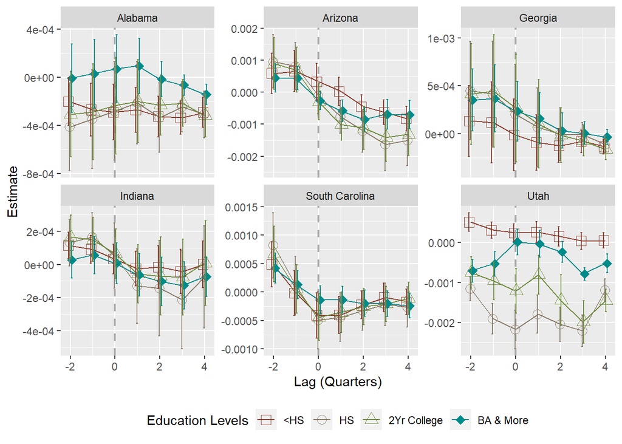

```r
visuals_lag_data = fread('reg_result/v16_edu_table.csv')
visuals_lag_data = visuals_lag_data[lawduration == '1 year']
visuals_lag_data = visuals_lag_data[education != 'E0']
visuals_lag_data = visuals_lag_data[education != 'E5' & regModel == 4 & industry == '00']

visual_lag_input = as.data.table(expand.grid(depdVar = unique(visuals_lag_data$depdVar),stringsAsFactors = F))
i = 3
i.depdVar = visual_lag_input[i,]$depdVar

plot_dt = visuals_lag_data[depdVar == i.depdVar]
plot_dt[, state_names := state]
plot_dt$state_names = mapvalues(plot_dt$state_names, from = c(1,4,13,18,45,49), to = c('Alabama','Arizona','Georgia','Indiana','South Carolina','Utah'))

ggplot(plot_dt, aes(x=nlead, y=est, color= education, group = education)) +
  geom_line() +
  geom_point(aes(shape = education), size = 3.4, position=position_dodge(.21), alpha=4) +
  scale_shape_manual(
    "Education Levels",
    values=c(0, 1, 2, 18),
    breaks = c("E1", "E2", "E3", "E4"),
    labels = c("<HS", "HS", "2Yr College","BA & More")) +
  scale_colour_manual(
    "Education Levels",
    values = c("coral4","bisque4","darkolivegreen4","darkcyan"),
    breaks = c("E1", "E2", "E3", "E4"),
    labels = c("<HS", "HS", "2Yr College","BA & More")
  ) +
  geom_vline(xintercept=0, linetype="dashed", color = "darkgrey", size = 0.75) +
  geom_errorbar(aes(ymin=conf_lower, ymax=conf_upper), width=0.33, position=position_dodge(.21)) +
  facet_wrap(~state_names, scales='free_y') +
  theme(legend.position="bottom") +
  xlab("Lag (Quarters)") + ylab("Estimate")
```